# Assignment #2: Meta-analysis of Ocean Acidification Effects on Behaviour

u7457916 Youzhi Huang

2022/10/25

This is [My GitHub Repository](https://github.com/YouzhiHuang/Assignment-2Meta-analysis-of-Ocean-Acidification-Effects-on-Behaviour)

## **Load the necessary R Packages**

```r
# Install a load of packages that we'll use.
library(pacman)
p_load(bookdown, devtools, tidyverse, ggforce, GGally, flextable, latex2exp, png, magick, metafor, MASS, emmeans, R.rsp,viridis,patchwork)
# Install the orchaRd package
# devtools::install_github("daniel1noble/orchaRd", force = TRUE)
library(orchaRd)
```

## **Add the article by [Clark et al. (2020)](https://doi.org/10.1038/s41586-019-1903-y) to the Meta-analysis dataset**

### 1. Analysis of [Clark et al. (2020)](https://doi.org/10.1038/s41586-019-1903-y) for each of the fish species’ `average activity` for each treatment.

First, we load the data and clean it

```r
# Load data file from the data folder
path <- "./data/OA_activitydat_20190302_BIOL3207.csv"
data <- read_csv(path)
```

```r
# Code to removing missing data
comp_data <-  data %>% drop_na()
# Drop irrelevant columns
Sp_Tr <- comp_data %>% dplyr::select(-c(...1,comment,loc,animal_id,sl,size))
# Check spelling in species and treatment but also generate a summary table
unique(Sp_Tr$species)
```

```
## [1] "ambon"     "lemon"     "chromis"   "acantho"   "humbug"    "whitedams"
```

```r
unique(Sp_Tr$treatment)
```

```
## [1] "CO2"     "control"
```

Well, the data is good without problems. Next we statistically analyse this data by [Clark et al. (2020)](https://doi.org/10.1038/s41586-019-1903-y).

```r
# Use flextable to render the summary table in a tidy format
use_df_printer()
set_flextable_defaults(
  theme_fun = theme_booktabs,
  big.mark = " ",
  font.color = "#666666",
  border.color = "#666666",
  padding = 3,
)
# Create a summary of the original dataset.
dat <- Sp_Tr %>%
  group_by(treatment,species) %>%
  summarise(n=n(),
    across(
      where(is.numeric),
      .fns = list(
        avg = ~ mean(.x, na.rm = TRUE),
        sd = ~ sd(.x, na.rm = TRUE)
      )
    ),.groups = "drop" ) %>%
  subset(select=-c(n_avg,n_sd))
fdata <-  as_tibble(dat)
# Use flextable to render the summary table
ft <-  fdata%>%
  flextable() %>%
  separate_header() %>%
  merge_v(j = c("treatment","species")) %>%
  theme_booktabs(bold_header = TRUE)  %>%
  valign(j = 1, valign = "top") %>%
  align(align = "center", part = "all", j = 4:5)%>%
  colformat_double(digits = 2)  %>%
  autofit()   %>%
  footnote(i = 2, j = grep("avg", colnames(fdata), value = TRUE),
           part = "header",
           ref_symbols = " ",
            value = as_paragraph("avg: Arithmetic Mean")) %>%
  footnote(i = 2, j = grep("sd", colnames(fdata), value = TRUE),
           part = "header",
           ref_symbols = " ", value = as_paragraph("sd: Standard Deviation"))
ft
```

| treatment | species | n | activity avg | activity sd |
| --- | --- | --- | --- | --- |
| CO2 | acantho | 86 | 27.30 | 10.42 |
|  | ambon | 22 | 18.39 | 12.20 |
|  | chromis | 14 | 24.78 | 10.98 |
|  | humbug | 62 | 40.28 | 11.92 |
|  | lemon | 19 | 26.04 | 10.96 |
|  | whitedams | 60 | 24.46 | 9.95 |
| control | acantho | 90 | 28.93 | 11.25 |
|  | ambon | 21 | 17.34 | 11.45 |
|  | chromis | 20 | 26.10 | 9.13 |
|  | humbug | 65 | 34.92 | 13.87 |
|  | lemon | 30 | 19.80 | 12.26 |
|  | whitedams | 61 | 26.59 | 10.94 |

avg: Arithmetic Mean  
sd: Standard Deviation

So, we have generated the summary statistics (means, SD, N) for each of the fish species’ average activity for each treatment.  
We next merge these statistics from [Clark et al. (2020)](https://doi.org/10.1038/s41586-019-1903-y) into a form used for meta-analysis.

### 2. Merge the summary statistics generated from from [Clark et al. (2020)](https://doi.org/10.1038/s41586-019-1903-y) with the metadata

```r
# Load data file from the data folder
matadata <- read_csv("./data/clark_paper_data.csv")
```

Collation of data from [Clark et al. (2020)](https://doi.org/10.1038/s41586-019-1903-y) into a form ready for Meta-analysis

```r
# Turn and statistics into wide data for merging
wider <- pivot_wider(fdata,names_from = treatment, values_from = c(n,activity_avg,activity_sd))
names(wider) <- c("Species","oa.n","ctrl.n","oa.mean","ctrl.mean","oa.sd","ctrl.sd")
# Repeat metadata to accommodate statistics
matadatarep <- matadata[rep(seq_len(nrow(matadata)),each=6),]
# Merge them and look at the result
meta_clark <- bind_cols(matadatarep,wider)
meta_clark
```

| Study character | Authors character | Year (online) numeric | Year (print) numeric | Title character | Journal character | Pub year IF numeric | 2017 IF numeric | Average n numeric | Effect type character | Climate (FishBase) character | Env cue/stimulus? character | Cue/stimulus type logical | Behavioural metric character | Life stage character | Species character | oa.n integer | ctrl.n integer | oa.mean numeric | ctrl.mean numeric | oa.sd numeric | ctrl.sd numeric |
| --- | --- | --- | --- | --- | --- | --- | --- | --- | --- | --- | --- | --- | --- | --- | --- | --- | --- | --- | --- | --- | --- |
| a92 | Clark et al | 2 020 | 2 020 | Ocean acidification does not impair the behaviour of coral reef fishes | Nature | 69.5 | 41.6 | 45 | Weak | Trop | No |  | Activity | Adult | acantho | 86 | 90 | 27.3 | 28.9 | 10.4 | 11.2 |
| a92 | Clark et al | 2 020 | 2 020 | Ocean acidification does not impair the behaviour of coral reef fishes | Nature | 69.5 | 41.6 | 45 | Weak | Trop | No |  | Activity | Adult | ambon | 22 | 21 | 18.4 | 17.3 | 12.2 | 11.5 |
| a92 | Clark et al | 2 020 | 2 020 | Ocean acidification does not impair the behaviour of coral reef fishes | Nature | 69.5 | 41.6 | 45 | Weak | Trop | No |  | Activity | Adult | chromis | 14 | 20 | 24.8 | 26.1 | 11.0 | 9.1 |
| a92 | Clark et al | 2 020 | 2 020 | Ocean acidification does not impair the behaviour of coral reef fishes | Nature | 69.5 | 41.6 | 45 | Weak | Trop | No |  | Activity | Adult | humbug | 62 | 65 | 40.3 | 34.9 | 11.9 | 13.9 |
| a92 | Clark et al | 2 020 | 2 020 | Ocean acidification does not impair the behaviour of coral reef fishes | Nature | 69.5 | 41.6 | 45 | Weak | Trop | No |  | Activity | Adult | lemon | 19 | 30 | 26.0 | 19.8 | 11.0 | 12.3 |
| a92 | Clark et al | 2 020 | 2 020 | Ocean acidification does not impair the behaviour of coral reef fishes | Nature | 69.5 | 41.6 | 45 | Weak | Trop | No |  | Activity | Adult | whitedams | 60 | 61 | 24.5 | 26.6 | 10.0 | 10.9 |

Great, we have converted the data from [Clark et al. (2020)](https://doi.org/10.1038/s41586-019-1903-y) into a form ready for meta-analysis.  
Next, we merge the collated data from [Clark et al. (2020)](https://doi.org/10.1038/s41586-019-1903-y) with the larger set of metadata.

### 3. Merge metadata from larger meta-analysis datase

```r
ocean_matadata <- read_csv("./data/ocean_meta_data.csv")
```

```r
oceanmatadata <- merge(x = ocean_matadata, y = meta_clark, all = TRUE)
oceanmatadata
```

| Study character | Authors character | Year (online) numeric | Year (print) numeric | Title character | Journal character | Pub year IF character | 2017 IF character | Average n numeric | Effect type character | Species character | Climate (FishBase) character | Env cue/stimulus? character | Cue/stimulus type character | Behavioural metric character | Life stage character | ctrl.n numeric | ctrl.mean numeric | ctrl.sd numeric | oa.n numeric | oa.mean numeric | oa.sd numeric |
| --- | --- | --- | --- | --- | --- | --- | --- | --- | --- | --- | --- | --- | --- | --- | --- | --- | --- | --- | --- | --- | --- |
| a1 | Munday et al | 2 009 | 2 009 | Ocean acidification impairs olfactory discrimination and homing ability of marine fish. | PNAS | 9.432 | 9.504 | 27 | Strong | Amphiprion percula | Trop | Yes | Habitat | % time in anemone cue | Larvae | 10 | 98.8 | 1.9 | 16 | 88.3 | 7.0 |
| a1 | Munday et al | 2 009 | 2 009 | Ocean acidification impairs olfactory discrimination and homing ability of marine fish. | PNAS | 9.432 | 9.504 | 27 | Strong | Amphiprion percula | Trop | Yes | Habitat | % time in Grass cue | Larvae | 20 | 46.4 | 14.0 | 46 | 71.4 | 13.3 |
| a1 | Munday et al | 2 009 | 2 009 | Ocean acidification impairs olfactory discrimination and homing ability of marine fish. | PNAS | 9.432 | 9.504 | 27 | Strong | Amphiprion percula | Trop | Yes | Habitat | % time in Melaleuca cue | Larvae | 20 | 0.8 | 3.5 | 46 | 83.6 | 10.6 |
| a1 | Munday et al | 2 009 | 2 009 | Ocean acidification impairs olfactory discrimination and homing ability of marine fish. | PNAS | 9.432 | 9.504 | 27 | Strong | Amphiprion percula | Trop | Yes | Habitat | % time in Xanthostemon cue | Larvae | 26 | 94.1 | 3.0 | 46 | 72.8 | 13.3 |
| a1 | Munday et al | 2 009 | 2 009 | Ocean acidification impairs olfactory discrimination and homing ability of marine fish. | PNAS | 9.432 | 9.504 | 27 | Strong | Amphiprion percula | Trop | Yes | Kin | % time in Non-parent vs Parent cue | Larvae | 30 | 96.3 | 4.0 | 20 | 49.6 | 2.4 |
| a1 | Munday et al | 2 009 | 2 009 | Ocean acidification impairs olfactory discrimination and homing ability of marine fish. | PNAS | 9.432 | 9.504 | 27 | Strong | Amphiprion percula | Trop | Yes | Kin | % time in Non-parent vs Seawater cue | Larvae | 30 | 90.9 | 4.0 | 20 | 99.8 | 0.0 |
| a1 | Munday et al | 2 009 | 2 009 | Ocean acidification impairs olfactory discrimination and homing ability of marine fish. | PNAS | 9.432 | 9.504 | 27 | Strong | Amphiprion percula | Trop | Yes | Kin | % time in Parent vs Seawater cue | Larvae | 30 | 0.9 | 3.0 | 20 | 99.8 | 0.0 |
| a10 | Domenici et al | 2 011 | 2 012 | Elevated carbon dioxide affects behavioural lateralization in a coral reef fish | Biol Lett | 3.762 | 3.345 | 69 | Strong | Neopomacentrus azysron | Trop | No | - | Absolute lateralization | Larvae | 70 | 46.8 | 30.6 | 68 | 29.1 | 24.1 |
| a11 | Ferrari et al | 2 012 | 2 012 | Effects of Ocean Acidification on Learning in Coral Reef Fishes | PLOS One | 3.73 | 2.766 | 17 | Strong | Pomacentrus amboinensis | Trop | No | - | Change in line crosses, na<95>ve tutor, water, Fig 2 | Juvenile | 17 | -6.0 | 13.9 | 17 | -7.0 | 16.5 |
| a11 | Ferrari et al | 2 012 | 2 012 | Effects of Ocean Acidification on Learning in Coral Reef Fishes | PLOS One | 3.73 | 2.766 | 17 | Strong | Pomacentrus amboinensis | Trop | No | - | Change in feeding strikes, na<95>ve tutor, water, Fig 2 | Juvenile | 17 | -2.3 | 10.1 | 17 | -4.2 | 15.2 |

n: 824

Combining the data from [Clark et al. (2020)](https://doi.org/10.1038/s41586-019-1903-y) into a larger meta-dataset form [Clements et al. (2022)](https://doi.org/10.1371/journal.pbio.3001511) gives us the full dataset available for meta-analysis. But don’t forget to collate the data before analysis for the subsequent Meta-analysis.

```r
# Rebuild the variable name avoiding spaces
names(oceanmatadata)[3:4] <- c("Year_online","Year_print")
names(oceanmatadata)[7:10] <- c("Pub_year_IF","IF_2017","Average_n","Effect_type")
names(oceanmatadata)[12:16] <- c("Climate_FishBase","Env_cue/stimulus?","Cue/stimulus_type","Behavioural_metric","Life_stage")
# Correct all the variables type
oceanmatadata$Pub_year_IF <- as.numeric(oceanmatadata$Pub_year_IF)
oceanmatadata$IF_2017 <- as.numeric(oceanmatadata$IF_2017)
# check spell
unique(sort(oceanmatadata$Species))
```

```
##  [1] "acantho"                        "Acanthochromis polyacanthus"
##  [3] "Acanthopagrus schlegelii"       "ambon"
##  [5] "Amphiprion melanopus"           "Amphiprion percula"
##  [7] "Anguilla anguilla"              "Apogon cyanosoma"
##  [9] "Argyrosomus japonicus"          "Argyrosomus regius"
## [11] "Atherina presbyter"             "Boreogadus saida"
## [13] "Cephalopholis cyanostigma"      "Cheilodipterus quinquelineatus"
## [15] "chromis"                        "Chromis punctipinnis"
## [17] "Chromis viridis"                "Citharichthys stigmaeus"
## [19] "Clupea harengus"                "Coryphaena hippurus"
## [21] "Ctenolabrus rupestris"          "Dascyllus aruanus"
## [23] "Dicentrachus labrax"            "Dicentrarchus labrax"
## [25] "Engraulis japonicus"            "Favonigobius lateralis"
## [27] "Forsterygion lapillum"          "Gadus macrocephalus"
## [29] "Gadus morhua"                   "Gasterosteus aculeatus"
```

[output cut: 16 more lines]

We can find that the species nomenclature of [Clark et al. (2020)](https://doi.org/10.1038/s41586-019-1903-y) differs from that of [Clements et al. (2022)](https://doi.org/10.1371/journal.pbio.3001511). By reviewing [the original literature](https://doi.org/10.1038/s41586-019-1903-y) of Clark et al. we were able to unify their species nomenclature into a binomial approach consistent with [Clements et al. (2022)](https://doi.org/10.1371/journal.pbio.3001511).

```r
oceanmatadata$Species[oceanmatadata$Species == "acantho"] <- "Acanthochromis polyacanthus"
oceanmatadata$Species[oceanmatadata$Species == "ambon"] <- "Pomacentrus amboinensis"
oceanmatadata$Species[oceanmatadata$Species == "chromis"] <- "Chromis atripectoralis"
oceanmatadata$Species[oceanmatadata$Species == "humbug"] <- "Dascyllus aruanus"
oceanmatadata$Species[oceanmatadata$Species == "lemon"] <- "Pomacentrus moluccensis"
oceanmatadata$Species[oceanmatadata$Species == "whitedams"] <- "Dischistodus perspicillatus"
summary(oceanmatadata)
```

```
##     Study             Authors           Year_online     Year_print
##  Length:824         Length:824         Min.   :2009   Min.   :2009
##  Class :character   Class :character   1st Qu.:2012   1st Qu.:2013
##  Mode  :character   Mode  :character   Median :2015   Median :2015
##                                        Mean   :2015   Mean   :2015
##                                        3rd Qu.:2017   3rd Qu.:2018
##                                        Max.   :2020   Max.   :2020
##
##     Title             Journal           Pub_year_IF      IF_2017
##  Length:824         Length:824         Min.   : 0.8   Min.   : 0.8
##  Class :character   Class :character   1st Qu.: 2.5   1st Qu.: 2.5
##  Mode  :character   Mode  :character   Median : 3.7   Median : 3.3
##                                        Mean   : 5.9   Mean   : 5.9
##                                        3rd Qu.: 8.0   3rd Qu.: 9.0
##                                        Max.   :69.5   Max.   :41.6
##                                        NA's   :24     NA's   :15
##    Average_n   Effect_type          Species          Climate_FishBase
##  Min.   :  4   Length:824         Length:824         Length:824
##  1st Qu.: 12   Class :character   Class :character   Class :character
##  Median : 17   Mode  :character   Mode  :character   Mode  :character
##  Mean   : 29
##  3rd Qu.: 30
##  Max.   :568
##
##  Env_cue/stimulus?  Cue/stimulus_type  Behavioural_metric  Life_stage
##  Length:824         Length:824         Length:824         Length:824
##  Class :character   Class :character   Class :character   Class :character
##  Mode  :character   Mode  :character   Mode  :character   Mode  :character
##
##
##
##
##      ctrl.n      ctrl.mean         ctrl.sd           oa.n        oa.mean
##  Min.   :  4   Min.   :   -70   Min.   :    0   Min.   :  2   Min.   :   -60
##  1st Qu.: 10   1st Qu.:     1   1st Qu.:    1   1st Qu.: 11   1st Qu.:     1
##  Median : 18   Median :    10   Median :    6   Median : 18   Median :    12
##  Mean   : 29   Mean   :   436   Mean   :  104   Mean   : 29   Mean   :   435
##  3rd Qu.: 30   3rd Qu.:    43   3rd Qu.:   22   3rd Qu.: 34   3rd Qu.:    43
##  Max.   :752   Max.   :154937   Max.   :25490   Max.   :755   Max.   :157061
##
##      oa.sd
##  Min.   :    0
##  1st Qu.:    1
##  Median :    7
##  Mean   :  114
##  3rd Qu.:   22
##  Max.   :36812
##
```

We can roughly see that there are unusual elements in the metadata set. So we can go back to the original literature to check the origin of these anomalous data. But we find that this data is correct, so we can leave it until a subsequent problem arises. This merged metadata can now be meta-analysed. So we can now perform a meta-analysis on this merged metadata.

## **Meta-analytical model for ocean acidification metadata sets**

First, we have to calculate the effect size(log response ratio, lnRR) we used for the meta-analysis.

### 4. Calculate the log response ratio (lnRR) effect size for every row

lnRR is defined as
$$lnRR = ln \left( \frac{M_E}{M_C}\right)$$
where $M_E$ and $M_C$ are the average measured response in the experimental and control treatments, respectively. So in order to calculate lnRR, we have to first filter the NA values and NaN values resulting from the calculation.

```r
# Exclude some NA's in sample size and r
cleanoceanmatadata <- oceanmatadata[complete.cases(oceanmatadata$ctrl.mean) & complete.cases(oceanmatadata$oa.mean)& complete.cases(oceanmatadata$ctrl.sd)& complete.cases(oceanmatadata$oa.sd)& complete.cases(oceanmatadata$ctrl.n)& complete.cases(oceanmatadata$oa.n),]
cleanInRRdata <- cleanoceanmatadata %>% filter(oa.mean/ctrl.mean >=0)
```

Calculate lnRR and add them to our meta dataset.

```r
InRRdata <-  metafor::escalc(measure="ROM", m1i=oa.mean,  m2i=ctrl.mean, sd1i=oa.sd, sd2i=ctrl.sd, n1i=oa.n, n2i=ctrl.n, data=cleanInRRdata,var.names = c("lnRR", "V_lnRR"))
```

### 5. Meta-analytic model fitted to the data

Our data are now ready for analysis. A multilevel meta-analytic model including the random effects of the study and observations can be built first.  
To estimate the variance of the random effects between the study (i.e. `Study`) and within-study (i.e. `Observation`) grouping variables, to control for non-independence and to understand the sources driving the variability in effect sizes. We had to create a new `Observation` variable not available in the original metadata set for estimating random effects at the observation/row level.

```r
# Create a new `Observation` variable
InRRdata$Observation <- rep(1:nrow(InRRdata))
```

Next we model the multilevel meta-analysis using `rma.mv` with the formula lnRR ~ 1. lnRR is our response variable and an ‘intercept’ is estimated which is the overall average estimate of lnRR, our effect size. t-test specifies the test statistic used. `Metafor` defaults to z-values based on the standard normal distribution, however, simulations show ([Pappalardo et al. 2020](https://doi.org/10.1111/2041-210X.13445)) and recommend ([Rosenberg 2013](https://doi.org/10.23943/princeton/9780691137285.003.0009)) using a t-distribution because sample sizes are typically small and estimates of true variance tests are used.

```r
#Multi-level meta-analytic model
MLMA <- metafor::rma.mv(lnRR  ~ 1, V = V_lnRR, method = "REML", random=list( ~1|Study,~1|Observation),test = "t",data=InRRdata)
```

```r
MLMA
```

```
##
## Multivariate Meta-Analysis Model (k = 801; method: REML)
##
## Variance Components:
##
##             estim    sqrt  nlvls  fixed       factor
## sigma^2.1  0.4732  0.6879     92     no        Study
## sigma^2.2  4.0110  2.0028    801     no  Observation
##
## Test for Heterogeneity:
## Q(df = 800) = 736089064.6199, p-val < .0001
##
## Model Results:
##
## estimate      se    tval   df    pval    ci.lb   ci.ub
##   0.1264  0.1128  1.1207  800  0.2627  -0.0950  0.3478
##
## ---
## Signif. codes:  0 '***' 0.001 '**' 0.01 '*' 0.05 '.' 0.1 ' ' 1
```

### 6. Results and discussion of the meta-analytical model

#### Uncertainty in the overall meta-analysis mean: 95% confidence interval

Based on the results of our multilevel meta-analysis model, a 95% confidence interval ranging from -0.095to0.348 can be obtained. In other words, at 95%, our point estimate expects the true mean to fall between the InRR values of -0.095to0.348, which spans 0 point, suggesting that the expected lnRR effect value could be 0, i.e. that ocean acidification has no effect on fish behaviour. This does not reject the original hypothesis that lnRR equals 0. We can see this from the p-value > 0.05. More precisely, the p-value is 0.263,the overall meta-analytic mean estimate is0.126

#### Heterogeneity in effect size estimates across studies

Because the meta-analysis mean estimates need to be interpreted in the context of how much variation in impact exists within studies (`Observations`) and between studies (`Studies`). Next we need report the variability measure also known as “heterogeneity”.

```r
# Calculate I2
i2_vals <- orchaRd::i2_ml(MLMA)
# Make a pretty table. First, lets clean up the names of the different I2 estimates. Lets remove I2_. It's a string, so, we can use some regular expressions to fix that. `gsub` is pretty useful. You put a pattern in and tell it what you would like to replace the text with. In this case, just blank will do! Then, we'll make the first letter of what is left capitalised.
i2 <- tibble(type = firstup(gsub("I2_", "", names(i2_vals))), I2 = i2_vals)
# Now, lets make a pretty table. We can so some nice modifications here too.
flextable(i2) %>%
    align(part = "header", align = "center") %>%
    compose(part = "header", j = 1, value = as_paragraph(as_b("Type"))) %>%
    compose(part = "header", j = 2, value = as_paragraph(as_b("I"), as_b(as_sup("2")),
        as_b("(%)")))
```

Table 1: Total effect size hetereogneity (Total), as well as the proportion of hetereogeneity in effects resulting from Study and Observation

| Type | I2(%) |
| --- | --- |
| Total | 100.0 |
| Study | 10.6 |
| Observation | 89.4 |

From Table 1, we have that the sampling variation accounts for only 0 % of the total variation in effects, and we can see that this metadata set has this extremely heterogeneous effect size. From the meta-analytic model in Table 1, we find that the total change in effect size estimates has 10.553 % as a result of between-study variation and 89.447% as a result of within-study/Observations variation.  
We can use not only $I^2$ estimates but also prediction intervals to quantify heterogeneity.

```r
# Calculate the prediction intervals
pis <- predict(MLMA)
pis
```

```
##
##    pred     se   ci.lb  ci.ub   pi.lb  pi.ub
##  0.1264 0.1128 -0.0950 0.3478 -4.0362 4.2890
```

We can see that our 95% prediction intervals are wide. Effect sizes (lnRR) are expected to range from -4.036 to 4.289 95% of the time with repeated experiments, suggesting a lot of inconsistency between studies. The fact that it crosses the 0 point suggests that if we were to repeat the experiment we might conclude that ocean acidification has no effect on fish activity.  
Next, we can visualise the results of these meta-analyses via forest plots.

#### Forest plot to capture meta-analysis model results.

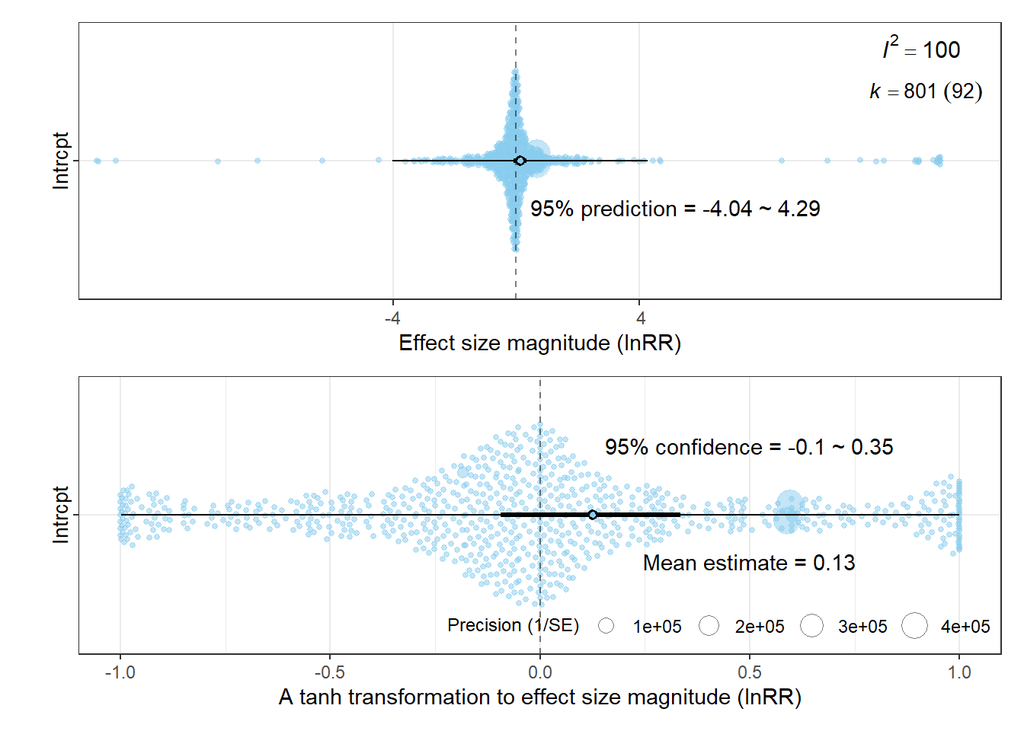

Figure 1: Forest plot of meta-analysis model results

```r
# Make an orchard plot using the model object
p1 <- orchaRd::orchard_plot(MLMA, group = "Study", data = InRRdata,
    xlab = "Effect size magnitude (lnRR)",transfm = "none",legend.pos= "none")+
  annotate(geom="text", x= 1.5, y= 13.2, label= paste0("italic(I)^{2} == ", round(i2_vals[1],1)),
           color="black", parse = TRUE, size = 4)+
  annotate(geom="text", x= 0.8, y= 5.2, label= paste0("95% prediction = ", round(predict(MLMA)[[5]],2)," ~ ", round(predict(MLMA)[[6]],2)))+
  scale_y_discrete(limits = c(-4, 4))
p2 <- orchaRd::orchard_plot(MLMA, group = "Study", data = InRRdata,
    xlab = "A tanh transformation to effect size magnitude (lnRR)",transf = "tanh",k=F,g=F)+
  annotate(geom="text", x= 1.3, y= 0.5, label= paste0("95% confidence = ", round(MLMA$ci.lb,2)," ~ ", round(MLMA$ci.ub,2)))+
  annotate(geom="text", x= 0.8, y= 0.5, label= paste0("Mean estimate = " ,round(MLMA$b,2)))
p1/p2
```

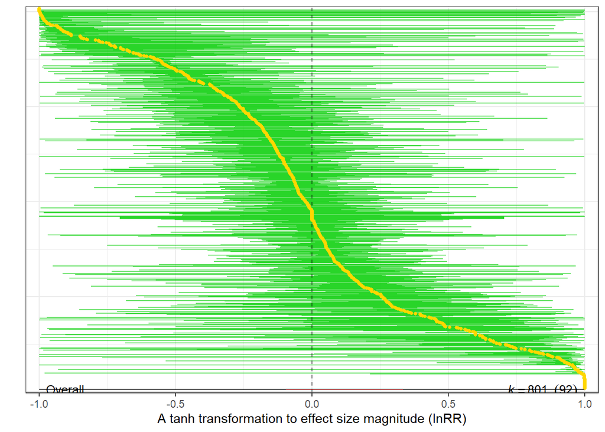

Figure 2: Caterpillars plot of meta-analysis model results

```r
# a caterpillar plot (not a caterpillars plot)
orchaRd::caterpillars(MLMA, group = "Study", data = InRRdata,
    xlab = "A tanh transformation to effect size magnitude (lnRR)",transfm = "tanh")
```

In Figure 1 the forest plot (orchard plot) and in Figure 2 the caterpillar plot because there are quite a few extreme values in the meta dataset. We have added the results of a tanh transformation to the effect size magnitude (lnRR) to show more detail.  
We present each of the important results from the previous meta-analysis in a forest plot (orchard plot) in Figure 1 : we show that across 92 studies, sample 801 (k), the horizontal axis represents the effect size (lnRR), the vertical axis represents the intercept i.e. the overall mean estimate of 0.126, the 95% confidence interval is -0.095 to 0.348, the 95% prediction interval is -4.036 to 4.289, and the overall index of heterogeneity ($I^{2}=100\%$. The effect sizes are scaled by the precision of each effect size value, i.e. $\frac1{\sqrt{V_{lnRR}}}$. We also plotted the Figure 2 caterpillar plots to show the CI for each effect size .We can see from the sparse middle of the graph and the dense top and bottom that when the effect size is around 0 the 95% confidence interval is small and the abnormal effect size tends to exhibit a large 95% confidence interval. This may be due to the small sample size.

From Figures 1 and 2, the overall estimates from the random effects meta-analysis of 801 effect sizes are centred on zero, with both the 95% confidence interval and the 95% prediction interval for the effect size crossing the no-effect line. Therefore, we can estimate that the effect size of the overall effect of ocean acidification on fish behaviour tends to be close to zero and is prevalent in studies that have conducted similar experiments on the effects of ocean acidification on fish behaviour.

## **Publication biases in meta-analyses of ocean acidification metadata sets**

### 7. Funnel plot for visually assessing the possibility of publication bias

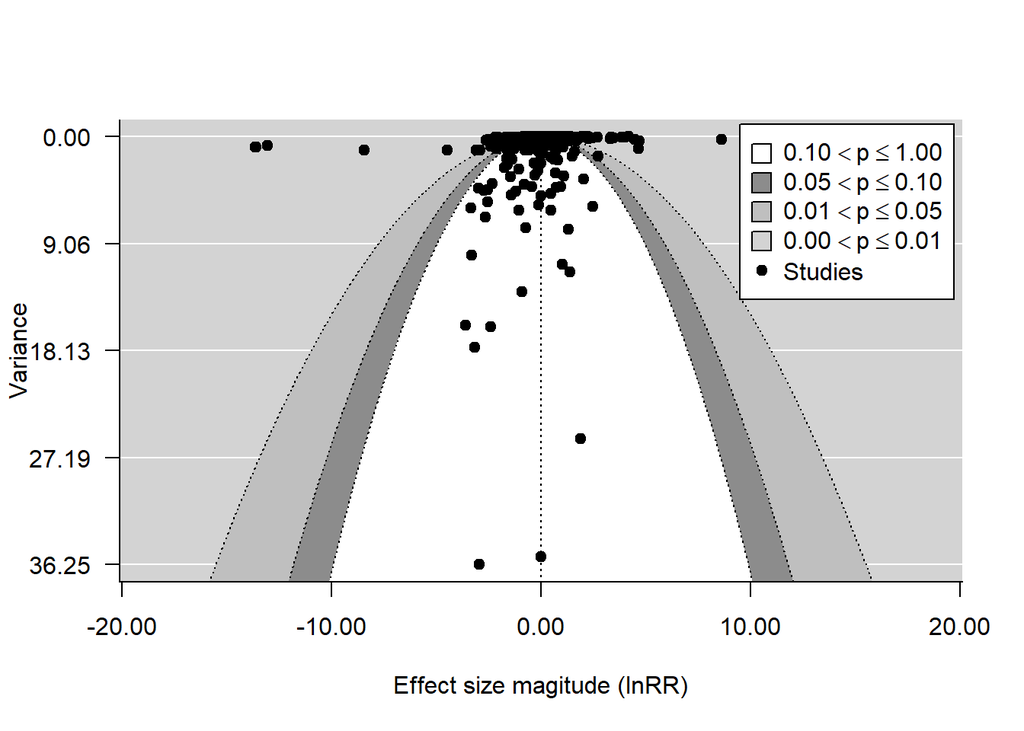

Figure 3: Contour-enhanced funnel plot of ocean acidification metadata sets

```r
# Lets make a funnel plot to visualize the data in relation to the precision. Note that one sample that was an extreme outlier was removed in the paper
nInRRdata <- InRRdata%>%filter(V_lnRR <= 1000)
funnel1 <- metafor::funnel(x = nInRRdata$lnRR, vi = nInRRdata$V_lnRR, yaxis="vi",
    digits = 2, level = c(0.1, 0.05, 0.01), shade = c("white", "gray55", "gray 75"),las = 1, xlab = "Effect size magitude (lnRR)", legend = TRUE)
```

The horizontal axis of Figure 3 represents the effect size (log response ratio, lnRR) and the vertical axis represents the sampling variance (V_lnRR). The theoretical pseudo-confidence region’s are shown with multiple p-values, showing the p-values corresponding to the different studies (black dots).

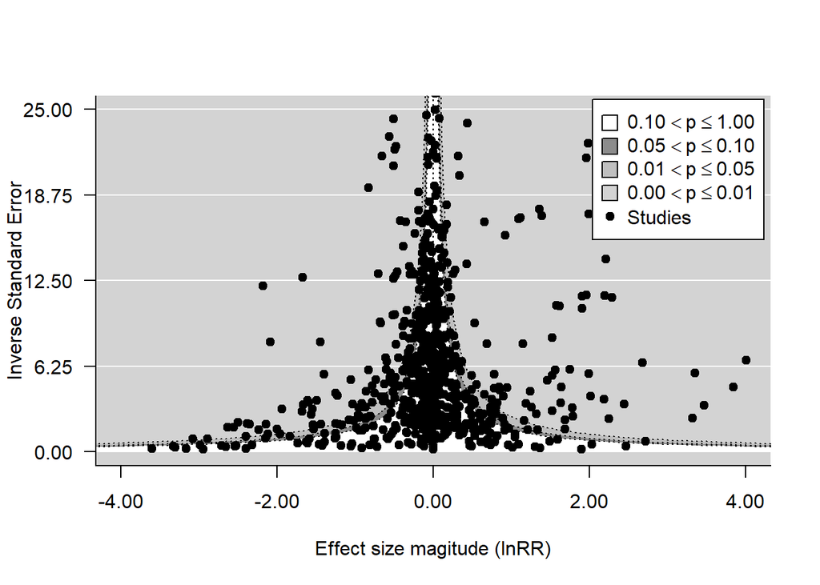

Figure 4: Contour-enhanced funnel plot of ocean acidification metadata sets(Partial zoom)

```r
# Lets make a funnel plot to visualize the data in relation to the precision. Note that one sample that was an extreme outlier was removed in the paper
metafor::funnel(x = nInRRdata$lnRR, vi = nInRRdata$V_lnRR, yaxis="seinv",
    digits = 2, level = c(0.1, 0.05, 0.01), shade = c("white", "gray55", "gray 75"),las = 1,ylim = c(0.001, 25),xlim = c(-4, 4), xlab = "Effect size magitude (lnRR)", legend = TRUE)
```

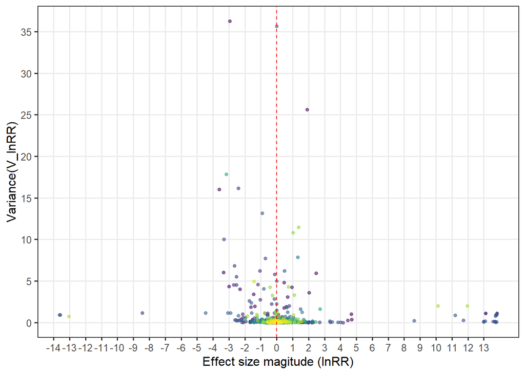

Figure 5: Funnel plot of ocean acidification metadata sets with colour

```r
funnel<- ggplot(nInRRdata,aes(x = lnRR, y= V_lnRR, color=Study))+
  geom_point(size=1.2,alpha=0.6)+
  scale_color_viridis(discrete=TRUE)+
  xlab("Effect size magitude (lnRR)")+
  ylab("Variance(V_lnRR)")+
  scale_x_continuous(breaks = round(seq(min(InRRdata$lnRR), max(InRRdata$lnRR), by = 1),0))+
  ylim(c(0,20))+
  scale_y_continuous(breaks = round(seq(0, 50, by = 5),1))+
  theme(legend.position = "NONE")+
  geom_vline(xintercept =0,linetype="dashed",color="red")+
  theme_bw(12)+
  theme(legend.position = "NONE")+
  theme(panel.grid.minor = element_blank())
funnel
```

In Figure 5, the horizontal axis represents the effect size (log response ratio, lnRR) and the vertical axis the sampling variance (V_lnRR). Different studies are shown in different colours, with the red line representing the no-effect size. Many extremes of effect sizes are shown.

```r
# Including sampling variance as moderator
metareg_v <- rma.mv(lnRR ~ V_lnRR, V = V_lnRR, random = list(~1 | Study, ~1 | Observation),
    test = "t", dfs = "contain", data = nInRRdata)
summary(metareg_v)
```

```
##
## Multivariate Meta-Analysis Model (k = 798; method: REML)
##
##     logLik    Deviance         AIC         BIC        AICc
## -1770.9688   3541.9376   3549.9376   3568.6560   3549.9881
##
## Variance Components:
##
##             estim    sqrt  nlvls  fixed       factor
## sigma^2.1  0.4745  0.6888     92     no        Study
## sigma^2.2  4.0121  2.0030    798     no  Observation
##
## Test for Residual Heterogeneity:
## QE(df = 796) = 736088799.1100, p-val < .0001
##
## Test of Moderators (coefficient 2):
## F(df1 = 1, df2 = 796) = 0.0069, p-val = 0.9338
##
## Model Results:
##
##          estimate      se    tval   df    pval    ci.lb   ci.ub
## intrcpt    0.1249  0.1142  1.0933   90  0.2772  -0.1021  0.3518
## V_lnRR     0.0056  0.0678  0.0830  796  0.9338  -0.1275  0.1388
##
## ---
## Signif. codes:  0 '***' 0.001 '**' 0.01 '*' 0.05 '.' 0.1 ' ' 1
```

```r
r2 <- orchaRd::r2_ml(metareg_v)
r2
```

```
##    R2_marginal R2_conditional
##       4.57e-05       1.06e-01
```

### 8. Time-lag plot assessing how effect sizes have changed through time.

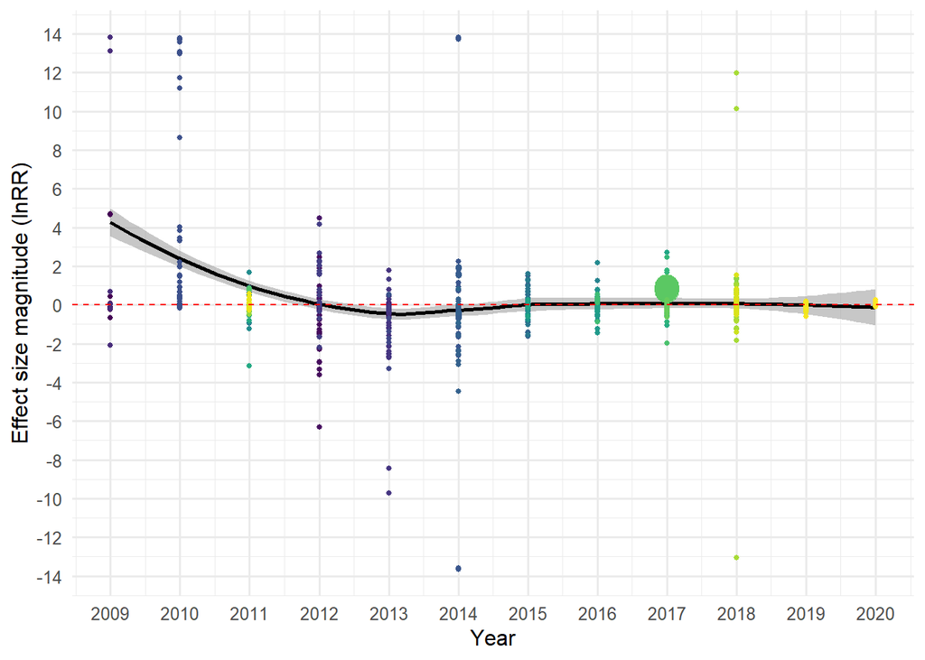

Figure 6: Time-lag plot of ocean acidification metadata sets

```r
Time_lag <- ggplot(InRRdata, aes(y = lnRR, x = Year_online, size=((InRRdata$Average_n)^5)*0.06)) +
    geom_smooth(aes(alpha=0.05),method = "loess",se=TRUE, fullrange=TRUE, level=0.95, color="black",show.legend = F)+
   geom_point(aes(color= InRRdata$Study), show.legend = F) +
  scale_color_viridis(discrete=TRUE)+
   geom_hline(yintercept =0,linetype="dashed",color="red")+
  labs(size = "Precision (N)")+
  xlab("Year")+ylab("Effect size magnitude (lnRR)")+
scale_x_continuous(breaks = round(seq(min(InRRdata$Year_online), max(InRRdata$Year_online), by = 1),1))+
  scale_y_continuous(breaks = round(seq(min(InRRdata$lnRR), 15, by = 2),0)) + theme_minimal(12)
Time_lag
```

In Figure 6, the horizontal axis shows when the study was published online (Year) and the vertical axis shows the effect size (log response ratio, lnRR). Different studies are represented by different colours and the precision of the study (mean sample size, N) is represented by different sizes, with the red line representing the no-effect size. The curve fits the average effect size for each year.

### 9. Formal meta-regression model that includes year as a moderator (fixed effect) to test for time-lag bias

```r
# Including sampling variance as moderator
metareg_time <- rma.mv(lnRR ~ Year_online, V = V_lnRR, random = list(~1 |Study, ~1 | Observation),test = "t", dfs = "contain", data = InRRdata)
```

```r
summary(metareg_time)
```

```
##
## Multivariate Meta-Analysis Model (k = 801; method: REML)
##
##     logLik    Deviance         AIC         BIC        AICc
## -1792.8764   3585.7527   3593.7527   3612.4862   3593.8031
##
## Variance Components:
##
##             estim    sqrt  nlvls  fixed       factor
## sigma^2.1  0.3984  0.6312     92     no        Study
## sigma^2.2  4.0113  2.0028    801     no  Observation
##
## Test for Residual Heterogeneity:
## QE(df = 799) = 128790497.0563, p-val < .0001
##
## Test of Moderators (coefficient 2):
## F(df1 = 1, df2 = 90) = 7.5020, p-val = 0.0074
##
## Model Results:
##
##              estimate       se     tval  df    pval    ci.lb     ci.ub
## intrcpt      223.4237  81.5241   2.7406  90  0.0074  61.4619  385.3856  **
## Year_online   -0.1108   0.0405  -2.7390  90  0.0074  -0.1912   -0.0304  **
##
## ---
## Signif. codes:  0 '***' 0.001 '**' 0.01 '*' 0.05 '.' 0.1 ' ' 1
```

```r
# time variation explain results were published in lnRR
r2_time <- orchaRd::r2_ml(metareg_time)
# Make a pretty table. First, lets clean up the names of the different I2 estimates. Lets remove I2_. It's a string, so, we can use some regular expressions to fix that. `gsub` is pretty useful. You put a pattern in and tell it what you would like to replace the text with. In this case, just blank will do! Then, we'll make the first letter of what is left capitalised.
r2_tim <- tibble(type = firstup(gsub("Percentage of variance in effect size", "", names(r2_time))),  Percentage= r2_time)
# Now, lets make a pretty table. We can so some nice modifications here too.
flextable(r2_tim) %>%
    align(part = "header", align = "center")
```

Table 2: Percentage of variance in effect size

| type | Percentage |
| --- | --- |
| R2_marginal | 0.0218 |
| R2_conditional | 0.1102 |

### 10. Formal meta-regression model that includes inverse sampling variance (i.e., 1/VlnRR) to test for file-drawer biases

```r
# Including sampling variance as moderators
metareg_time2 <- rma.mv(lnRR ~ 1/V_lnRR ,  V = V_lnRR,random = list(~1 |Study, ~1 | Observation),
    test = "t", dfs = "contain", data = InRRdata)
summary(metareg_time2)
```

```
##
## Multivariate Meta-Analysis Model (k = 801; method: REML)
##
##     logLik    Deviance         AIC         BIC        AICc
## -1798.4719   3596.9439   3602.9439   3616.9977   3602.9740
##
## Variance Components:
##
##             estim    sqrt  nlvls  fixed       factor
## sigma^2.1  0.4732  0.6879     92     no        Study
## sigma^2.2  4.0110  2.0028    801     no  Observation
##
## Test for Heterogeneity:
## Q(df = 800) = 736089064.6199, p-val < .0001
##
## Model Results:
##
## estimate      se    tval  df    pval    ci.lb   ci.ub
##   0.1264  0.1128  1.1207  91  0.2654  -0.0976  0.3505
##
## ---
## Signif. codes:  0 '***' 0.001 '**' 0.01 '*' 0.05 '.' 0.1 ' ' 1
```

```r
r2_time2 <- orchaRd::r2_ml(metareg_time2)
r2_time2
```

```
##    R2_marginal R2_conditional
##          0.000          0.106
```

```r
# Including sampling variance and mean centered year as moderators to account for both
InRRdata <- InRRdata %>%
    mutate(Year_c = Year_online - mean(Year_online))
metareg_time_c <- rma.mv(lnRR ~ Year_c + V_lnRR,  V = V_lnRR,random = list(~1 |Study, ~1 | Observation),
    test = "t", dfs = "contain", data = InRRdata)
summary(metareg_time_c)
```

```
##
## Multivariate Meta-Analysis Model (k = 801; method: REML)
##
##     logLik    Deviance         AIC         BIC        AICc
## -1782.5907   3565.1814   3575.1814   3598.5919   3575.2572
##
## Variance Components:
##
##             estim    sqrt  nlvls  fixed       factor
## sigma^2.1  0.3984  0.6312     92     no        Study
## sigma^2.2  4.0113  2.0028    801     no  Observation
##
## Test for Residual Heterogeneity:
## QE(df = 798) = 128790497.0561, p-val < .0001
##
## Test of Moderators (coefficients 2:3):
## F(df1 = 2, df2 = 89) = 3.7510, p-val = 0.0273
##
## Model Results:
##
##          estimate      se     tval   df    pval    ci.lb    ci.ub
## intrcpt    0.1460  0.1083   1.3476   89  0.1812  -0.0693   0.3613
## Year_c    -0.1108  0.0405  -2.7390   89  0.0074  -0.1912  -0.0304  **
## V_lnRR    -0.0000  0.0001  -0.0013  798  0.9989  -0.0002   0.0002
##
## ---
## Signif. codes:  0 '***' 0.001 '**' 0.01 '*' 0.05 '.' 0.1 ' ' 1
```

```r
r2_timec <- orchaRd::r2_ml(metareg_time_c)
r2_timec
```

```
##    R2_marginal R2_conditional
##         0.0811         0.1641
```

### 11. Discussion of the possibility of publication bias based on meta-regression results

Although there is no blank area in the bottom right corner of Figure 3, this may be due to the high precision (small sampling variance) of all these studies. The distribution of effect sizes in the funnel plot visualization in Figure 4 and Figure 5 is still relatively symmetrical funnel-shaped distribution, with no significant asymmetric publication bias. This can also be supported by the results of the fit test through the meta-analysis model (p=0.934, CI=-0.128~ 0.139). However, in Figure 3, we found high precision (small variance) in all of these experiments, which should have been concentrated at the top in a more concentrated area, but instead found that the difference in effect size was about the same as at the bottom, and that no significant spread occurred as it should have. It would be expected that as the sampling variance increases, the spread of effect sizes should increase, but in the funnel plot visualisation in Figure 3 Figure 5 there is no significant spread of effect sizes, instead effect sizes spread significantly even when the variance is small. That is, the effect size does not gradually fix as the sample size increases and the sampling variance decreases. This indicates that this effect size does not exist stably and may not be present.  
Not only that, but we find in Figure 3 that the studies with significant differences found in the contour-enhanced funnel plots tend to have very large effect sizes, and there is a clear selection bias for publication, i.e. a large number of non-significant results are not published (large number of missing studies in blank areas). In Figure 5 we find a number of studies with extremely extreme effect sizes and variances.

In Figure 6, which visualises the mean effect size with year of publication, we find an extremely significant time lag bias. There does appear to be a significant negative correlation between mean effect size and year. The initial studies had extremely extreme mean effect sizes, but as subsequent studies continued, the effect sizes converged to reasonable levels.  
It is also noteworthy that the earlier studies had smaller sample sizes (i.e. lower precision). However, these early studies appear to have higher (exaggerated) effects compared to studies conducted in later years.  
We can actually quantify time-lagged bias using multilevel meta-regression. Table 2 shows that the time lag explains 2.177 % of the variation in lnRR and has a significant effect with a p-value of 0.007 (p<0.05) and a 95% confidence interval of -0.191 to -0.03 , which does not cross the no-effect line, suggesting a stable effect variable. And with an estimated value of -0.111 , this stable and significant effect is negative.

We can actually create a model to account for these two effects and explain the possible covariance between the two. We can obtain the overall mean effect size (lnRR) of 0.146 when controlling for small sample and time lag bias as. We can even conclude that ocean acidification does not have a significant effect(p = 0.181, CI = -0.069~ 0.361) on fish behaviour when considering the two sources of publication bias. We find that in this combined model, again the time lag bias has a significant effect (p = 0.007, CI = -0.191~ -0.03) while the ‘file drawer’ effect does not have a significant effect (p = 0.999, CI = -1.605^{-4}~ 1.603^{-4}). This implies that there is publication bias. There is a “decline effect” of publication bias. This may be due to the initial researchers selectively reporting studies with significant effect sizes. They exaggerate effect sizes to attract attention, facilitate publication, attract citations and financial support.

### 12. Discuss publication bias with reference to the study by [Clements et al. (2022)](https://doi.org/10.1371/journal.pbio.3001511)

When comparing this with the study by [Clements et al. (2022)](https://doi.org/10.1371/journal.pbio.3001511), we find that we used lnRR when fitting the model for meta-analysis and when analysing publication bias whereas [Clements et al. (2022)](https://doi.org/10.1371/journal.pbio.3001511) used the absolute value of lnRR.  
This prompted us to revisit the significance of positive and negative InRR values, as many behavioural changes can be described by a positive and negative functional trade-off, i.e. the measures of fish behavioural change in this metadata set are heterogeneous.  
This means that a negative InRR effect size in one study does not offset a positive InRR effect size in another study, for example, even if ocean acidification has a significant effect on increased fish activity, it may manifest itself by making it more difficult for predators to catch prey in one study (negative InRR) and easier to notice prey in another (positive InRR). However, both studies actually support the idea that ocean acidification has a significant effect on fish behaviour (activity).  
Therefore, in order to obtain a more accurate analysis, the scale should also be harmonised in terms of assigning a functional direction to behavioural changes.  
Thus, we can scrutinise the original metadata set and find that functional directions are not assigned to behavioural changes due to inherent difficulties. They therefore convert individual effect sizes to absolute values, as positive and negative functional directions cannot simply cancel out. Although this would overestimate absolute effect sizes and complicate true population-level inferences, absolute values in their study still provide a measure of whether ocean acidification has an effect on fish behaviour and whether there is publication-biased variation in the effect sizes of such effects. It is also useful to know the strength of effects that ignore directionality([Frieder et al.,2013](https://doi.org/10.1093/schbul/sbt035), [László et al.,2006](https://doi.org/10.1093/beheco/ark005) ).  
So [Clements et al.(2022)](https://doi.org/10.1371/journal.pbio.3001511) first used the absolute value of lnRR for their analysis, and if after concluding with the absolute value analysis that ocean acidification does have an effect on fish behaviour, this could be further investigated by removing the absolute value and assigning a functional direction to the behavioural change in the next step.

However, [Clements et al. (2022)](https://doi.org/10.1371/journal.pbio.3001511) obtained no significant effect of ocean acidification on fish behaviour when analysed with absolute values. In particular, they reveal an extreme “downward effect” of ocean acidification on fish behaviour, i.e. a significant time-lag bias in this area. Over time, the effect sizes initially found to be significant and scientifically apparent gradually lose their strength and return to reasonable levels.This is consistent with what we have found previously. Such effects are prevalent not only in ecology and evolution, as described by [Clements et al. (2022)](https://doi.org/10.1371/journal.pbio.3001511), but in a range of scientific studies where similar experiments are conducted[Schooler (2011)](https://doi.org/10.1038/470437a). Effect sizes do change in the literature, but how this change is caused. [Clements et al. (2022)](https://doi.org/10.1371/journal.pbio.3001511) discuss three factors that may lead to changes in effect size including biology, methodology and publication practices and find that the recession effect solved in this area cannot be explained by 3 possible biological explanations including (1) cold water species; (2) non-olfactory related behaviour; and (3) non-larval life stages.

The key to this decline effect as discussed by [Schooler (2011)](https://doi.org/10.1038/470437a) and [Clements et al. (2022)](https://doi.org/10.1371/journal.pbio.3001511). is that the high effect size of the starting study overestimates reality. As the example of the effects of ocean acidification on fish behaviour, [Schooler (2011)](https://doi.org/10.1038/470437a) analysed two types of publication bias, namely methodological bias and publication practice bias, that influenced the variation in effect sizes. They found that the vast majority of high effect size studies in the field tended to be characterised by low sample sizes, but were published in high impact journals and had a disproportionate impact on the field in terms of citations. And these high effect size, low sample size preliminary studies may have originated from researcher academic misconduct. They express widespread concern about low sample sizes and selective publication, not only in the field of ocean acidification, but also in the wider scientific discipline. The effect of early exaggeration can have a huge impact on the scientific process and on scientists themselves.